# Risk Factor Analysis

## Outcome Variable

**Outcome Variable:** stunted

## Predictor Variables

**Intervention Variable:** enwast

**Adjustment Set:**

unadjusted

## Stratifying Variables

The analysis was stratified on these variable(s):

- agecat
- studyid
- country

## Data Summary

| agecat | studyid | country | enwast | stunted | n_cell | n |
| --- | --- | --- | --- | --- | --- | --- |
| Birth | ki0047075b-MAL-ED | BANGLADESH | 0 | 0 | 155 | 215 |
| Birth | ki0047075b-MAL-ED | BANGLADESH | 0 | 1 | 24 | 215 |
| Birth | ki0047075b-MAL-ED | BANGLADESH | 1 | 0 | 32 | 215 |
| Birth | ki0047075b-MAL-ED | BANGLADESH | 1 | 1 | 4 | 215 |
| Birth | ki0047075b-MAL-ED | BRAZIL | 0 | 0 | 54 | 62 |
| Birth | ki0047075b-MAL-ED | BRAZIL | 0 | 1 | 6 | 62 |
| Birth | ki0047075b-MAL-ED | BRAZIL | 1 | 0 | 2 | 62 |
| Birth | ki0047075b-MAL-ED | BRAZIL | 1 | 1 | 0 | 62 |
| Birth | ki0047075b-MAL-ED | INDIA | 0 | 0 | 33 | 45 |
| Birth | ki0047075b-MAL-ED | INDIA | 0 | 1 | 7 | 45 |
| Birth | ki0047075b-MAL-ED | INDIA | 1 | 0 | 4 | 45 |
| Birth | ki0047075b-MAL-ED | INDIA | 1 | 1 | 1 | 45 |
| Birth | ki0047075b-MAL-ED | NEPAL | 0 | 0 | 24 | 26 |
| Birth | ki0047075b-MAL-ED | NEPAL | 0 | 1 | 0 | 26 |
| Birth | ki0047075b-MAL-ED | NEPAL | 1 | 0 | 1 | 26 |
| Birth | ki0047075b-MAL-ED | NEPAL | 1 | 1 | 1 | 26 |
| Birth | ki0047075b-MAL-ED | PERU | 0 | 0 | 202 | 228 |
| Birth | ki0047075b-MAL-ED | PERU | 0 | 1 | 21 | 228 |
| Birth | ki0047075b-MAL-ED | PERU | 1 | 0 | 5 | 228 |
| Birth | ki0047075b-MAL-ED | PERU | 1 | 1 | 0 | 228 |
| Birth | ki0047075b-MAL-ED | SOUTH AFRICA | 0 | 0 | 100 | 121 |
| Birth | ki0047075b-MAL-ED | SOUTH AFRICA | 0 | 1 | 8 | 121 |
| Birth | ki0047075b-MAL-ED | SOUTH AFRICA | 1 | 0 | 13 | 121 |
| Birth | ki0047075b-MAL-ED | SOUTH AFRICA | 1 | 1 | 0 | 121 |
| Birth | ki0047075b-MAL-ED | TANZANIA, UNITED REPUBLIC OF | 0 | 0 | 102 | 115 |
| Birth | ki0047075b-MAL-ED | TANZANIA, UNITED REPUBLIC OF | 0 | 1 | 12 | 115 |
| Birth | ki0047075b-MAL-ED | TANZANIA, UNITED REPUBLIC OF | 1 | 0 | 0 | 115 |
| Birth | ki0047075b-MAL-ED | TANZANIA, UNITED REPUBLIC OF | 1 | 1 | 1 | 115 |
| Birth | ki1000108-CMC-V-BCS-2002 | INDIA | 0 | 0 | 66 | 87 |
| Birth | ki1000108-CMC-V-BCS-2002 | INDIA | 0 | 1 | 9 | 87 |

[output cut: 298 more lines]

The following strata were considered:

- agecat: 24 months, studyid: ki0047075b-MAL-ED, country: BANGLADESH
- agecat: 24 months, studyid: ki0047075b-MAL-ED, country: BRAZIL
- agecat: 24 months, studyid: ki0047075b-MAL-ED, country: INDIA
- agecat: 24 months, studyid: ki0047075b-MAL-ED, country: NEPAL
- agecat: 24 months, studyid: ki0047075b-MAL-ED, country: PERU
- agecat: 24 months, studyid: ki0047075b-MAL-ED, country: SOUTH AFRICA
- agecat: 24 months, studyid: ki0047075b-MAL-ED, country: TANZANIA, UNITED REPUBLIC OF
- agecat: 24 months, studyid: ki1000108-CMC-V-BCS-2002, country: INDIA
- agecat: 24 months, studyid: ki1000108-IRC, country: INDIA
- agecat: 24 months, studyid: ki1000109-EE, country: PAKISTAN
- agecat: 24 months, studyid: ki1017093-NIH-Birth, country: BANGLADESH
- agecat: 24 months, studyid: ki1017093b-PROVIDE, country: BANGLADESH
- agecat: 24 months, studyid: ki1017093c-NIH-Crypto, country: BANGLADESH
- agecat: 24 months, studyid: ki1066203-TanzaniaChild2, country: TANZANIA, UNITED REPUBLIC OF
- agecat: 24 months, studyid: ki1101329-Keneba, country: GAMBIA
- agecat: 24 months, studyid: ki1113344-GMS-Nepal, country: NEPAL
- agecat: 24 months, studyid: ki1114097-CMIN, country: BANGLADESH
- agecat: 24 months, studyid: ki1114097-CONTENT, country: PERU
- agecat: 24 months, studyid: ki1119695-PROBIT, country: BELARUS
- agecat: 24 months, studyid: ki1126311-ZVITAMBO, country: ZIMBABWE
- agecat: 24 months, studyid: ki1135781-COHORTS, country: GUATEMALA
- agecat: 24 months, studyid: ki1135781-COHORTS, country: INDIA
- agecat: 24 months, studyid: ki1135781-COHORTS, country: PHILIPPINES
- agecat: 24 months, studyid: ki1148112-LCNI-5, country: MALAWI
- agecat: 24 months, studyid: kiGH5241-JiVitA-3, country: BANGLADESH
- agecat: 24 months, studyid: kiGH5241-JiVitA-4, country: BANGLADESH
- agecat: 6 months, studyid: ki0047075b-MAL-ED, country: BANGLADESH
- agecat: 6 months, studyid: ki0047075b-MAL-ED, country: BRAZIL
- agecat: 6 months, studyid: ki0047075b-MAL-ED, country: INDIA
- agecat: 6 months, studyid: ki0047075b-MAL-ED, country: NEPAL
- agecat: 6 months, studyid: ki0047075b-MAL-ED, country: PERU
- agecat: 6 months, studyid: ki0047075b-MAL-ED, country: SOUTH AFRICA
- agecat: 6 months, studyid: ki0047075b-MAL-ED, country: TANZANIA, UNITED REPUBLIC OF
- agecat: 6 months, studyid: ki1000108-CMC-V-BCS-2002, country: INDIA
- agecat: 6 months, studyid: ki1000108-IRC, country: INDIA
- agecat: 6 months, studyid: ki1000109-EE, country: PAKISTAN
- agecat: 6 months, studyid: ki1000109-ResPak, country: PAKISTAN
- agecat: 6 months, studyid: ki1000304b-SAS-CompFeed, country: INDIA
- agecat: 6 months, studyid: ki1000304b-SAS-FoodSuppl, country: INDIA
- agecat: 6 months, studyid: ki1017093-NIH-Birth, country: BANGLADESH
- agecat: 6 months, studyid: ki1017093b-PROVIDE, country: BANGLADESH
- agecat: 6 months, studyid: ki1017093c-NIH-Crypto, country: BANGLADESH
- agecat: 6 months, studyid: ki1066203-TanzaniaChild2, country: TANZANIA, UNITED REPUBLIC OF
- agecat: 6 months, studyid: ki1101329-Keneba, country: GAMBIA
- agecat: 6 months, studyid: ki1112895-Guatemala BSC, country: GUATEMALA
- agecat: 6 months, studyid: ki1113344-GMS-Nepal, country: NEPAL
- agecat: 6 months, studyid: ki1114097-CMIN, country: BANGLADESH
- agecat: 6 months, studyid: ki1114097-CONTENT, country: PERU
- agecat: 6 months, studyid: ki1119695-PROBIT, country: BELARUS
- agecat: 6 months, studyid: ki1126311-ZVITAMBO, country: ZIMBABWE
- agecat: 6 months, studyid: ki1135781-COHORTS, country: GUATEMALA
- agecat: 6 months, studyid: ki1135781-COHORTS, country: INDIA
- agecat: 6 months, studyid: ki1135781-COHORTS, country: PHILIPPINES
- agecat: 6 months, studyid: ki1148112-LCNI-5, country: MALAWI
- agecat: 6 months, studyid: kiGH5241-JiVitA-3, country: BANGLADESH
- agecat: 6 months, studyid: kiGH5241-JiVitA-4, country: BANGLADESH
- agecat: Birth, studyid: ki0047075b-MAL-ED, country: BANGLADESH
- agecat: Birth, studyid: ki0047075b-MAL-ED, country: BRAZIL
- agecat: Birth, studyid: ki0047075b-MAL-ED, country: INDIA
- agecat: Birth, studyid: ki0047075b-MAL-ED, country: NEPAL
- agecat: Birth, studyid: ki0047075b-MAL-ED, country: PERU
- agecat: Birth, studyid: ki0047075b-MAL-ED, country: SOUTH AFRICA
- agecat: Birth, studyid: ki0047075b-MAL-ED, country: TANZANIA, UNITED REPUBLIC OF
- agecat: Birth, studyid: ki1000108-CMC-V-BCS-2002, country: INDIA
- agecat: Birth, studyid: ki1000108-IRC, country: INDIA
- agecat: Birth, studyid: ki1000109-EE, country: PAKISTAN
- agecat: Birth, studyid: ki1000109-ResPak, country: PAKISTAN
- agecat: Birth, studyid: ki1000304b-SAS-CompFeed, country: INDIA
- agecat: Birth, studyid: ki1017093-NIH-Birth, country: BANGLADESH
- agecat: Birth, studyid: ki1017093b-PROVIDE, country: BANGLADESH
- agecat: Birth, studyid: ki1017093c-NIH-Crypto, country: BANGLADESH
- agecat: Birth, studyid: ki1101329-Keneba, country: GAMBIA
- agecat: Birth, studyid: ki1113344-GMS-Nepal, country: NEPAL
- agecat: Birth, studyid: ki1114097-CMIN, country: BANGLADESH
- agecat: Birth, studyid: ki1114097-CONTENT, country: PERU
- agecat: Birth, studyid: ki1119695-PROBIT, country: BELARUS
- agecat: Birth, studyid: ki1126311-ZVITAMBO, country: ZIMBABWE
- agecat: Birth, studyid: ki1135781-COHORTS, country: GUATEMALA
- agecat: Birth, studyid: ki1135781-COHORTS, country: INDIA
- agecat: Birth, studyid: ki1135781-COHORTS, country: PHILIPPINES
- agecat: Birth, studyid: kiGH5241-JiVitA-3, country: BANGLADESH
- agecat: Birth, studyid: kiGH5241-JiVitA-4, country: BANGLADESH

### Dropped Strata

Some strata were dropped due to rare outcomes:

- agecat: Birth, studyid: ki0047075b-MAL-ED, country: BANGLADESH
- agecat: Birth, studyid: ki0047075b-MAL-ED, country: BRAZIL
- agecat: Birth, studyid: ki0047075b-MAL-ED, country: INDIA
- agecat: Birth, studyid: ki0047075b-MAL-ED, country: NEPAL
- agecat: Birth, studyid: ki0047075b-MAL-ED, country: PERU
- agecat: Birth, studyid: ki0047075b-MAL-ED, country: SOUTH AFRICA
- agecat: Birth, studyid: ki0047075b-MAL-ED, country: TANZANIA, UNITED REPUBLIC OF
- agecat: Birth, studyid: ki1000108-CMC-V-BCS-2002, country: INDIA
- agecat: Birth, studyid: ki1000108-IRC, country: INDIA
- agecat: Birth, studyid: ki1000109-ResPak, country: PAKISTAN
- agecat: Birth, studyid: ki1114097-CMIN, country: BANGLADESH
- agecat: Birth, studyid: ki1114097-CONTENT, country: PERU
- agecat: Birth, studyid: ki1119695-PROBIT, country: BELARUS
- agecat: Birth, studyid: ki1135781-COHORTS, country: GUATEMALA
- agecat: 6 months, studyid: ki0047075b-MAL-ED, country: BRAZIL
- agecat: 6 months, studyid: ki0047075b-MAL-ED, country: NEPAL
- agecat: 6 months, studyid: ki0047075b-MAL-ED, country: PERU
- agecat: 6 months, studyid: ki0047075b-MAL-ED, country: SOUTH AFRICA
- agecat: 6 months, studyid: ki0047075b-MAL-ED, country: TANZANIA, UNITED REPUBLIC OF
- agecat: 6 months, studyid: ki1112895-Guatemala BSC, country: GUATEMALA
- agecat: 6 months, studyid: ki1114097-CONTENT, country: PERU
- agecat: 24 months, studyid: ki0047075b-MAL-ED, country: BRAZIL
- agecat: 24 months, studyid: ki0047075b-MAL-ED, country: PERU
- agecat: 24 months, studyid: ki0047075b-MAL-ED, country: SOUTH AFRICA
- agecat: 24 months, studyid: ki0047075b-MAL-ED, country: TANZANIA, UNITED REPUBLIC OF
- agecat: 24 months, studyid: ki1066203-TanzaniaChild2, country: TANZANIA, UNITED REPUBLIC OF
- agecat: 24 months, studyid: ki1114097-CONTENT, country: PERU
- agecat: 24 months, studyid: ki1148112-LCNI-5, country: MALAWI

## Methods Detail

We’re interested in the causal parameters $E[Y_a]$ for all values of $a \in \mathcal{A}$. These parameters represent the mean outcome if, possibly contrary to fact, we intervened to set all units to have $A=a$. Under the randomization and positivity assumptions, these are identified by the statistical parameters $\psi_a=E_W[E_{Y|A,W}(Y|A=a,W)]$. In addition, we’re interested in the mean of $Y$, $E[Y]$ under no intervention (the observed mean). We will estimate these parameters by using SuperLearner to fit the relevant likelihood factors – $E_{Y|A,W}(Y|A=a,W)$ and $p(A=a|W)$, and then updating our likelihood fit using a joint TMLE.

For unadjusted analyses ($W=\{\}$), initial likelihoods were estimated using Lrnr_glm to estimate the simple $E(Y|A)$ and Lrnr_mean to estimate $p(A)$. For adjusted analyses, a small library containing Lrnr_glmnet, Lrnr_xgboost, and Lrnr_mean was used.

Having estimated these parameters, we will then use the delta method to estimate relative risks and attributable risks relative to a prespecified baseline level of $A$.

# Results Detail

## Results Plots

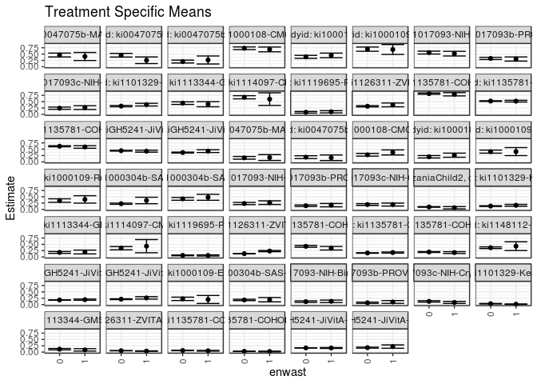

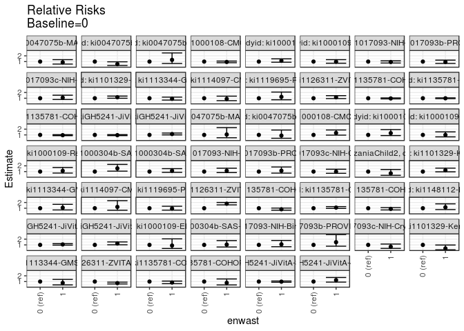

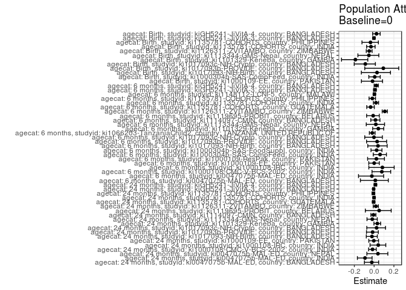

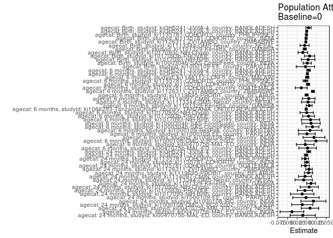

## Results Table

### Parameter: TSM

| agecat | studyid | country | intervention_level | baseline_level | estimate | ci_lower | ci_upper |
| --- | --- | --- | --- | --- | --- | --- | --- |
| Birth | ki1000109-EE | PAKISTAN | 0 | NA | 0.2258065 | 0.1598002 | 0.2918127 |
| Birth | ki1000109-EE | PAKISTAN | 1 | NA | 0.2000000 | 0.0427655 | 0.3572345 |
| Birth | ki1000304b-SAS-CompFeed | INDIA | 0 | NA | 0.1817259 | 0.1557751 | 0.2076767 |
| Birth | ki1000304b-SAS-CompFeed | INDIA | 1 | NA | 0.1916667 | 0.1058706 | 0.2774627 |
| Birth | ki1017093-NIH-Birth | BANGLADESH | 0 | NA | 0.1154791 | 0.0844027 | 0.1465556 |
| Birth | ki1017093-NIH-Birth | BANGLADESH | 1 | NA | 0.1271676 | 0.0774794 | 0.1768559 |
| Birth | ki1017093b-PROVIDE | BANGLADESH | 0 | NA | 0.0698795 | 0.0453281 | 0.0944310 |
| Birth | ki1017093b-PROVIDE | BANGLADESH | 1 | NA | 0.1025641 | 0.0475387 | 0.1575895 |
| Birth | ki1017093c-NIH-Crypto | BANGLADESH | 0 | NA | 0.1252336 | 0.0971675 | 0.1532998 |
| Birth | ki1017093c-NIH-Crypto | BANGLADESH | 1 | NA | 0.0842697 | 0.0434319 | 0.1251075 |
| Birth | ki1101329-Keneba | GAMBIA | 0 | NA | 0.0335753 | 0.0229364 | 0.0442142 |
| Birth | ki1101329-Keneba | GAMBIA | 1 | NA | 0.0129534 | 0.0016694 | 0.0242373 |
| Birth | ki1113344-GMS-Nepal | NEPAL | 0 | NA | 0.1159136 | 0.0880818 | 0.1437453 |
| Birth | ki1113344-GMS-Nepal | NEPAL | 1 | NA | 0.0882353 | 0.0405287 | 0.1359419 |
| Birth | ki1126311-ZVITAMBO | ZIMBABWE | 0 | NA | 0.0556374 | 0.0513254 | 0.0599495 |
| Birth | ki1126311-ZVITAMBO | ZIMBABWE | 1 | NA | 0.0402505 | 0.0321035 | 0.0483974 |
| Birth | ki1135781-COHORTS | INDIA | 0 | NA | 0.0637630 | 0.0570548 | 0.0704711 |
| Birth | ki1135781-COHORTS | INDIA | 1 | NA | 0.0529101 | 0.0398802 | 0.0659400 |
| Birth | ki1135781-COHORTS | PHILIPPINES | 0 | NA | 0.0306373 | 0.0238094 | 0.0374651 |
| Birth | ki1135781-COHORTS | PHILIPPINES | 1 | NA | 0.0238095 | 0.0099054 | 0.0377137 |
| Birth | kiGH5241-JiVitA-3 | BANGLADESH | 0 | NA | 0.1660744 | 0.1597464 | 0.1724024 |
| Birth | kiGH5241-JiVitA-3 | BANGLADESH | 1 | NA | 0.1632855 | 0.1461412 | 0.1804298 |
| Birth | kiGH5241-JiVitA-4 | BANGLADESH | 0 | NA | 0.1761706 | 0.1573219 | 0.1950194 |
| Birth | kiGH5241-JiVitA-4 | BANGLADESH | 1 | NA | 0.2190083 | 0.1534264 | 0.2845901 |
| 6 months | ki0047075b-MAL-ED | BANGLADESH | 0 | NA | 0.1595745 | 0.1071117 | 0.2120372 |
| 6 months | ki0047075b-MAL-ED | BANGLADESH | 1 | NA | 0.1707317 | 0.0553037 | 0.2861597 |
| 6 months | ki0047075b-MAL-ED | INDIA | 0 | NA | 0.1851852 | 0.1296859 | 0.2406845 |
| 6 months | ki0047075b-MAL-ED | INDIA | 1 | NA | 0.1627907 | 0.0522089 | 0.2733725 |
| 6 months | ki1000108-CMC-V-BCS-2002 | INDIA | 0 | NA | 0.2794118 | 0.2260133 | 0.3328102 |
| 6 months | ki1000108-CMC-V-BCS-2002 | INDIA | 1 | NA | 0.3736264 | 0.2740946 | 0.4731582 |

[output cut: 78 more lines]

### Parameter: E(Y)

| agecat | studyid | country | intervention_level | baseline_level | estimate | ci_lower | ci_upper |
| --- | --- | --- | --- | --- | --- | --- | --- |
| Birth | ki1000109-EE | PAKISTAN | NA | NA | 0.2222222 | 0.1613186 | 0.2831258 |
| Birth | ki1000304b-SAS-CompFeed | INDIA | NA | NA | 0.1828054 | 0.1605315 | 0.2050793 |
| Birth | ki1017093-NIH-Birth | BANGLADESH | NA | NA | 0.1189655 | 0.0925952 | 0.1453359 |
| Birth | ki1017093b-PROVIDE | BANGLADESH | NA | NA | 0.0770677 | 0.0543836 | 0.0997518 |
| Birth | ki1017093c-NIH-Crypto | BANGLADESH | NA | NA | 0.1150070 | 0.0915734 | 0.1384407 |
| Birth | ki1101329-Keneba | GAMBIA | NA | NA | 0.0282258 | 0.0198080 | 0.0366436 |
| Birth | ki1113344-GMS-Nepal | NEPAL | NA | NA | 0.1100775 | 0.0859045 | 0.1342505 |
| Birth | ki1126311-ZVITAMBO | ZIMBABWE | NA | NA | 0.0530095 | 0.0491714 | 0.0568475 |
| Birth | ki1135781-COHORTS | INDIA | NA | NA | 0.0617878 | 0.0558091 | 0.0677665 |
| Birth | ki1135781-COHORTS | PHILIPPINES | NA | NA | 0.0295533 | 0.0233992 | 0.0357074 |
| Birth | kiGH5241-JiVitA-3 | BANGLADESH | NA | NA | 0.1657624 | 0.1596821 | 0.1718426 |
| Birth | kiGH5241-JiVitA-4 | BANGLADESH | NA | NA | 0.1804919 | 0.1622043 | 0.1987794 |
| 6 months | ki0047075b-MAL-ED | BANGLADESH | NA | NA | 0.1615721 | 0.1137975 | 0.2093466 |
| 6 months | ki0047075b-MAL-ED | INDIA | NA | NA | 0.1810345 | 0.1313803 | 0.2306886 |
| 6 months | ki1000108-CMC-V-BCS-2002 | INDIA | NA | NA | 0.3030303 | 0.2556886 | 0.3503720 |
| 6 months | ki1000108-IRC | INDIA | NA | NA | 0.2198953 | 0.1783071 | 0.2614835 |
| 6 months | ki1000109-EE | PAKISTAN | NA | NA | 0.4041096 | 0.3477284 | 0.4604908 |
| 6 months | ki1000109-ResPak | PAKISTAN | NA | NA | 0.3596491 | 0.2972205 | 0.4220777 |
| 6 months | ki1000304b-SAS-CompFeed | INDIA | NA | NA | 0.2407255 | 0.2138448 | 0.2676061 |
| 6 months | ki1000304b-SAS-FoodSuppl | INDIA | NA | NA | 0.4289474 | 0.3791199 | 0.4787748 |
| 6 months | ki1017093-NIH-Birth | BANGLADESH | NA | NA | 0.2431907 | 0.2060665 | 0.2803148 |
| 6 months | ki1017093b-PROVIDE | BANGLADESH | NA | NA | 0.1507538 | 0.1220277 | 0.1794798 |
| 6 months | ki1017093c-NIH-Crypto | BANGLADESH | NA | NA | 0.1930836 | 0.1636957 | 0.2224715 |
| 6 months | ki1066203-TanzaniaChild2 | TANZANIA, UNITED REPUBLIC OF | NA | NA | 0.0960396 | 0.0831873 | 0.1088919 |
| 6 months | ki1101329-Keneba | GAMBIA | NA | NA | 0.1375062 | 0.1225178 | 0.1524945 |
| 6 months | ki1113344-GMS-Nepal | NEPAL | NA | NA | 0.1837121 | 0.1506498 | 0.2167744 |
| 6 months | ki1114097-CMIN | BANGLADESH | NA | NA | 0.3534483 | 0.2918020 | 0.4150945 |
| 6 months | ki1119695-PROBIT | BELARUS | NA | NA | 0.0625873 | 0.0488338 | 0.0763408 |
| 6 months | ki1126311-ZVITAMBO | ZIMBABWE | NA | NA | 0.1466846 | 0.1390145 | 0.1543548 |
| 6 months | ki1135781-COHORTS | GUATEMALA | NA | NA | 0.4062153 | 0.3741290 | 0.4383016 |
| 6 months | ki1135781-COHORTS | INDIA | NA | NA | 0.1611862 | 0.1522521 | 0.1701204 |
| 6 months | ki1135781-COHORTS | PHILIPPINES | NA | NA | 0.1932125 | 0.1780130 | 0.2084119 |
| 6 months | ki1148112-LCNI-5 | MALAWI | NA | NA | 0.3682956 | 0.3356382 | 0.4009530 |
| 6 months | kiGH5241-JiVitA-3 | BANGLADESH | NA | NA | 0.1814799 | 0.1738720 | 0.1890878 |
| 6 months | kiGH5241-JiVitA-4 | BANGLADESH | NA | NA | 0.2158730 | 0.2021674 | 0.2295786 |
| 24 months | ki0047075b-MAL-ED | BANGLADESH | NA | NA | 0.4527363 | 0.3837514 | 0.5217212 |
| 24 months | ki0047075b-MAL-ED | INDIA | NA | NA | 0.4170404 | 0.3521799 | 0.4819008 |
| 24 months | ki0047075b-MAL-ED | NEPAL | NA | NA | 0.2133333 | 0.1596859 | 0.2669808 |
| 24 months | ki1000108-CMC-V-BCS-2002 | INDIA | NA | NA | 0.7197802 | 0.6735800 | 0.7659804 |
| 24 months | ki1000108-IRC | INDIA | NA | NA | 0.4073107 | 0.3580395 | 0.4565819 |
| 24 months | ki1000109-EE | PAKISTAN | NA | NA | 0.6934307 | 0.6159409 | 0.7709205 |
| 24 months | ki1017093-NIH-Birth | BANGLADESH | NA | NA | 0.5476773 | 0.4993820 | 0.5959725 |
| 24 months | ki1017093b-PROVIDE | BANGLADESH | NA | NA | 0.3245614 | 0.2860904 | 0.3630324 |
| 24 months | ki1017093c-NIH-Crypto | BANGLADESH | NA | NA | 0.2480000 | 0.2101093 | 0.2858907 |
| 24 months | ki1101329-Keneba | GAMBIA | NA | NA | 0.3351222 | 0.3125235 | 0.3577210 |
| 24 months | ki1113344-GMS-Nepal | NEPAL | NA | NA | 0.4329670 | 0.3873894 | 0.4785447 |
| 24 months | ki1114097-CMIN | BANGLADESH | NA | NA | 0.6681034 | 0.6073788 | 0.7288281 |
| 24 months | ki1119695-PROBIT | BELARUS | NA | NA | 0.0850694 | 0.0559313 | 0.1142076 |
| 24 months | ki1126311-ZVITAMBO | ZIMBABWE | NA | NA | 0.3235880 | 0.2999438 | 0.3472323 |
| 24 months | ki1135781-COHORTS | GUATEMALA | NA | NA | 0.8130477 | 0.7891917 | 0.8369037 |
| 24 months | ki1135781-COHORTS | INDIA | NA | NA | 0.5218935 | 0.5081423 | 0.5356447 |
| 24 months | ki1135781-COHORTS | PHILIPPINES | NA | NA | 0.6131231 | 0.5934151 | 0.6328312 |
| 24 months | kiGH5241-JiVitA-3 | BANGLADESH | NA | NA | 0.4385529 | 0.4244156 | 0.4526902 |
| 24 months | kiGH5241-JiVitA-4 | BANGLADESH | NA | NA | 0.3733488 | 0.3557063 | 0.3909913 |

### Parameter: RR

| agecat | studyid | country | intervention_level | baseline_level | estimate | ci_lower | ci_upper |
| --- | --- | --- | --- | --- | --- | --- | --- |
| Birth | ki1000109-EE | PAKISTAN | 0 | 0 | 1.0000000 | 1.0000000 | 1.0000000 |
| Birth | ki1000109-EE | PAKISTAN | 1 | 0 | 0.8857143 | 0.3828476 | 2.0490918 |
| Birth | ki1000304b-SAS-CompFeed | INDIA | 0 | 0 | 1.0000000 | 1.0000000 | 1.0000000 |
| Birth | ki1000304b-SAS-CompFeed | INDIA | 1 | 0 | 1.0547020 | 0.6350702 | 1.7516118 |
| Birth | ki1017093-NIH-Birth | BANGLADESH | 0 | 0 | 1.0000000 | 1.0000000 | 1.0000000 |
| Birth | ki1017093-NIH-Birth | BANGLADESH | 1 | 0 | 1.1012176 | 0.6852171 | 1.7697752 |
| Birth | ki1017093b-PROVIDE | BANGLADESH | 0 | 0 | 1.0000000 | 1.0000000 | 1.0000000 |
| Birth | ki1017093b-PROVIDE | BANGLADESH | 1 | 0 | 1.4677277 | 0.7729141 | 2.7871461 |
| Birth | ki1017093c-NIH-Crypto | BANGLADESH | 0 | 0 | 1.0000000 | 1.0000000 | 1.0000000 |
| Birth | ki1017093c-NIH-Crypto | BANGLADESH | 1 | 0 | 0.6728995 | 0.3945224 | 1.1477012 |
| Birth | ki1101329-Keneba | GAMBIA | 0 | 0 | 1.0000000 | 1.0000000 | 1.0000000 |
| Birth | ki1101329-Keneba | GAMBIA | 1 | 0 | 0.3858003 | 0.1526824 | 0.9748462 |
| Birth | ki1113344-GMS-Nepal | NEPAL | 0 | 0 | 1.0000000 | 1.0000000 | 1.0000000 |
| Birth | ki1113344-GMS-Nepal | NEPAL | 1 | 0 | 0.7612164 | 0.4212920 | 1.3754128 |
| Birth | ki1126311-ZVITAMBO | ZIMBABWE | 0 | 0 | 1.0000000 | 1.0000000 | 1.0000000 |
| Birth | ki1126311-ZVITAMBO | ZIMBABWE | 1 | 0 | 0.7234419 | 0.5824737 | 0.8985268 |
| Birth | ki1135781-COHORTS | INDIA | 0 | 0 | 1.0000000 | 1.0000000 | 1.0000000 |
| Birth | ki1135781-COHORTS | INDIA | 1 | 0 | 0.8297924 | 0.6348444 | 1.0846051 |
| Birth | ki1135781-COHORTS | PHILIPPINES | 0 | 0 | 1.0000000 | 1.0000000 | 1.0000000 |
| Birth | ki1135781-COHORTS | PHILIPPINES | 1 | 0 | 0.7771429 | 0.4159519 | 1.4519732 |
| Birth | kiGH5241-JiVitA-3 | BANGLADESH | 0 | 0 | 1.0000000 | 1.0000000 | 1.0000000 |
| Birth | kiGH5241-JiVitA-3 | BANGLADESH | 1 | 0 | 0.9832067 | 0.8818048 | 1.0962693 |
| Birth | kiGH5241-JiVitA-4 | BANGLADESH | 0 | 0 | 1.0000000 | 1.0000000 | 1.0000000 |
| Birth | kiGH5241-JiVitA-4 | BANGLADESH | 1 | 0 | 1.2431601 | 0.9057969 | 1.7061738 |
| 6 months | ki0047075b-MAL-ED | BANGLADESH | 0 | 0 | 1.0000000 | 1.0000000 | 1.0000000 |
| 6 months | ki0047075b-MAL-ED | BANGLADESH | 1 | 0 | 1.0699187 | 0.5044964 | 2.2690470 |
| 6 months | ki0047075b-MAL-ED | INDIA | 0 | 0 | 1.0000000 | 1.0000000 | 1.0000000 |
| 6 months | ki0047075b-MAL-ED | INDIA | 1 | 0 | 0.8790698 | 0.4183849 | 1.8470161 |
| 6 months | ki1000108-CMC-V-BCS-2002 | INDIA | 0 | 0 | 1.0000000 | 1.0000000 | 1.0000000 |
| 6 months | ki1000108-CMC-V-BCS-2002 | INDIA | 1 | 0 | 1.3371891 | 0.9634013 | 1.8560020 |

[output cut: 78 more lines]

### Parameter: PAR

| agecat | studyid | country | intervention_level | baseline_level | estimate | ci_lower | ci_upper |
| --- | --- | --- | --- | --- | --- | --- | --- |
| Birth | ki1000109-EE | PAKISTAN | 0 | NA | -0.0035842 | -0.0273046 | 0.0201362 |
| Birth | ki1000304b-SAS-CompFeed | INDIA | 0 | NA | 0.0010795 | -0.0094607 | 0.0116198 |
| Birth | ki1017093-NIH-Birth | BANGLADESH | 0 | NA | 0.0034864 | -0.0139998 | 0.0209726 |
| Birth | ki1017093b-PROVIDE | BANGLADESH | 0 | NA | 0.0071882 | -0.0061132 | 0.0204895 |
| Birth | ki1017093c-NIH-Crypto | BANGLADESH | 0 | NA | -0.0102266 | -0.0226657 | 0.0022124 |
| Birth | ki1101329-Keneba | GAMBIA | 0 | NA | -0.0053495 | -0.0093987 | -0.0013003 |
| Birth | ki1113344-GMS-Nepal | NEPAL | 0 | NA | -0.0058360 | -0.0175144 | 0.0058423 |
| Birth | ki1126311-ZVITAMBO | ZIMBABWE | 0 | NA | -0.0026280 | -0.0042054 | -0.0010505 |
| Birth | ki1135781-COHORTS | INDIA | 0 | NA | -0.0019752 | -0.0046444 | 0.0006940 |
| Birth | ki1135781-COHORTS | PHILIPPINES | 0 | NA | -0.0010840 | -0.0035449 | 0.0013769 |
| Birth | kiGH5241-JiVitA-3 | BANGLADESH | 0 | NA | -0.0003121 | -0.0023046 | 0.0016805 |
| Birth | kiGH5241-JiVitA-4 | BANGLADESH | 0 | NA | 0.0043213 | -0.0025726 | 0.0112151 |
| 6 months | ki0047075b-MAL-ED | BANGLADESH | 0 | NA | 0.0019976 | -0.0207098 | 0.0247049 |
| 6 months | ki0047075b-MAL-ED | INDIA | 0 | NA | -0.0041507 | -0.0271104 | 0.0188090 |
| 6 months | ki1000108-CMC-V-BCS-2002 | INDIA | 0 | NA | 0.0236185 | -0.0050078 | 0.0522449 |
| 6 months | ki1000108-IRC | INDIA | 0 | NA | 0.0184028 | -0.0098357 | 0.0466412 |
| 6 months | ki1000109-EE | PAKISTAN | 0 | NA | 0.0001880 | -0.0212980 | 0.0216741 |
| 6 months | ki1000109-ResPak | PAKISTAN | 0 | NA | 0.0082978 | -0.0223129 | 0.0389085 |
| 6 months | ki1000304b-SAS-CompFeed | INDIA | 0 | NA | 0.0144685 | -0.0023016 | 0.0312386 |
| 6 months | ki1000304b-SAS-FoodSuppl | INDIA | 0 | NA | 0.0109409 | -0.0128087 | 0.0346906 |
| 6 months | ki1017093-NIH-Birth | BANGLADESH | 0 | NA | 0.0094950 | -0.0143634 | 0.0333534 |
| 6 months | ki1017093b-PROVIDE | BANGLADESH | 0 | NA | 0.0045673 | -0.0107216 | 0.0198562 |
| 6 months | ki1017093c-NIH-Crypto | BANGLADESH | 0 | NA | -0.0003400 | -0.0175132 | 0.0168332 |
| 6 months | ki1066203-TanzaniaChild2 | TANZANIA, UNITED REPUBLIC OF | 0 | NA | -0.0018036 | -0.0045870 | 0.0009797 |
| 6 months | ki1101329-Keneba | GAMBIA | 0 | NA | 0.0058791 | -0.0018236 | 0.0135818 |
| 6 months | ki1113344-GMS-Nepal | NEPAL | 0 | NA | 0.0031896 | -0.0138060 | 0.0201851 |
| 6 months | ki1114097-CMIN | BANGLADESH | 0 | NA | 0.0048244 | -0.0114980 | 0.0211468 |
| 6 months | ki1119695-PROBIT | BELARUS | 0 | NA | -0.0006153 | -0.0046438 | 0.0034132 |
| 6 months | ki1126311-ZVITAMBO | ZIMBABWE | 0 | NA | 0.0158909 | 0.0119888 | 0.0197929 |
| 6 months | ki1135781-COHORTS | GUATEMALA | 0 | NA | -0.0144743 | -0.0300252 | 0.0010765 |
| 6 months | ki1135781-COHORTS | INDIA | 0 | NA | 0.0030953 | -0.0011476 | 0.0073381 |
| 6 months | ki1135781-COHORTS | PHILIPPINES | 0 | NA | -0.0035013 | -0.0098103 | 0.0028076 |
| 6 months | ki1148112-LCNI-5 | MALAWI | 0 | NA | 0.0010229 | -0.0034161 | 0.0054618 |
| 6 months | kiGH5241-JiVitA-3 | BANGLADESH | 0 | NA | 0.0015051 | -0.0009758 | 0.0039859 |
| 6 months | kiGH5241-JiVitA-4 | BANGLADESH | 0 | NA | 0.0046511 | 0.0000760 | 0.0092261 |
| 24 months | ki0047075b-MAL-ED | BANGLADESH | 0 | NA | -0.0106783 | -0.0432412 | 0.0218846 |
| 24 months | ki0047075b-MAL-ED | INDIA | 0 | NA | -0.0385152 | -0.0691803 | -0.0078501 |
| 24 months | ki0047075b-MAL-ED | NEPAL | 0 | NA | 0.0082051 | -0.0144227 | 0.0308329 |
| 24 months | ki1000108-CMC-V-BCS-2002 | INDIA | 0 | NA | -0.0118374 | -0.0393941 | 0.0157193 |
| 24 months | ki1000108-IRC | INDIA | 0 | NA | 0.0169761 | -0.0154079 | 0.0493601 |
| 24 months | ki1000109-EE | PAKISTAN | 0 | NA | -0.0022215 | -0.0364043 | 0.0319613 |
| 24 months | ki1017093-NIH-Birth | BANGLADESH | 0 | NA | -0.0120497 | -0.0425584 | 0.0184590 |
| 24 months | ki1017093b-PROVIDE | BANGLADESH | 0 | NA | -0.0050846 | -0.0245167 | 0.0143474 |
| 24 months | ki1017093c-NIH-Crypto | BANGLADESH | 0 | NA | 0.0062418 | -0.0172481 | 0.0297316 |
| 24 months | ki1101329-Keneba | GAMBIA | 0 | NA | 0.0108977 | -0.0004296 | 0.0222250 |
| 24 months | ki1113344-GMS-Nepal | NEPAL | 0 | NA | -0.0081289 | -0.0306164 | 0.0143587 |
| 24 months | ki1114097-CMIN | BANGLADESH | 0 | NA | -0.0047076 | -0.0214330 | 0.0120178 |
| 24 months | ki1119695-PROBIT | BELARUS | 0 | NA | 0.0043261 | -0.0064812 | 0.0151334 |
| 24 months | ki1126311-ZVITAMBO | ZIMBABWE | 0 | NA | 0.0056088 | -0.0027916 | 0.0140093 |
| 24 months | ki1135781-COHORTS | GUATEMALA | 0 | NA | -0.0038859 | -0.0142391 | 0.0064672 |
| 24 months | ki1135781-COHORTS | INDIA | 0 | NA | -0.0004489 | -0.0064814 | 0.0055835 |
| 24 months | ki1135781-COHORTS | PHILIPPINES | 0 | NA | -0.0042725 | -0.0127124 | 0.0041674 |
| 24 months | kiGH5241-JiVitA-3 | BANGLADESH | 0 | NA | -0.0021198 | -0.0066360 | 0.0023964 |
| 24 months | kiGH5241-JiVitA-4 | BANGLADESH | 0 | NA | 0.0048476 | -0.0001061 | 0.0098014 |

### Parameter: PAF

| agecat | studyid | country | intervention_level | baseline_level | estimate | ci_lower | ci_upper |
| --- | --- | --- | --- | --- | --- | --- | --- |
| Birth | ki1000109-EE | PAKISTAN | 0 | NA | -0.0161290 | -0.1286362 | 0.0851629 |
| Birth | ki1000304b-SAS-CompFeed | INDIA | 0 | NA | 0.0059054 | -0.0535702 | 0.0620236 |
| Birth | ki1017093-NIH-Birth | BANGLADESH | 0 | NA | 0.0293060 | -0.1292682 | 0.1656128 |
| Birth | ki1017093b-PROVIDE | BANGLADESH | 0 | NA | 0.0932706 | -0.0945910 | 0.2488901 |
| Birth | ki1017093c-NIH-Crypto | BANGLADESH | 0 | NA | -0.0889218 | -0.2014277 | 0.0130486 |
| Birth | ki1101329-Keneba | GAMBIA | 0 | NA | -0.1895255 | -0.3298960 | -0.0639712 |
| Birth | ki1113344-GMS-Nepal | NEPAL | 0 | NA | -0.0530175 | -0.1641142 | 0.0474767 |
| Birth | ki1126311-ZVITAMBO | ZIMBABWE | 0 | NA | -0.0495754 | -0.0795614 | -0.0204222 |
| Birth | ki1135781-COHORTS | INDIA | 0 | NA | -0.0319669 | -0.0759832 | 0.0102489 |
| Birth | ki1135781-COHORTS | PHILIPPINES | 0 | NA | -0.0366792 | -0.1230298 | 0.0430318 |
| Birth | kiGH5241-JiVitA-3 | BANGLADESH | 0 | NA | -0.0018826 | -0.0139781 | 0.0100686 |
| Birth | kiGH5241-JiVitA-4 | BANGLADESH | 0 | NA | 0.0239416 | -0.0148229 | 0.0612254 |
| 6 months | ki0047075b-MAL-ED | BANGLADESH | 0 | NA | 0.0123634 | -0.1386338 | 0.1433365 |
| 6 months | ki0047075b-MAL-ED | INDIA | 0 | NA | -0.0229277 | -0.1578533 | 0.0962749 |
| 6 months | ki1000108-CMC-V-BCS-2002 | INDIA | 0 | NA | 0.0779412 | -0.0213620 | 0.1675895 |
| 6 months | ki1000108-IRC | INDIA | 0 | NA | 0.0836887 | -0.0536196 | 0.2031029 |
| 6 months | ki1000109-EE | PAKISTAN | 0 | NA | 0.0004653 | -0.0541432 | 0.0522448 |
| 6 months | ki1000109-ResPak | PAKISTAN | 0 | NA | 0.0230719 | -0.0658685 | 0.1045907 |
| 6 months | ki1000304b-SAS-CompFeed | INDIA | 0 | NA | 0.0601037 | -0.0088883 | 0.1243777 |
| 6 months | ki1000304b-SAS-FoodSuppl | INDIA | 0 | NA | 0.0255065 | -0.0315029 | 0.0793650 |
| 6 months | ki1017093-NIH-Birth | BANGLADESH | 0 | NA | 0.0390435 | -0.0641683 | 0.1322450 |
| 6 months | ki1017093b-PROVIDE | BANGLADESH | 0 | NA | 0.0302966 | -0.0764931 | 0.1264926 |
| 6 months | ki1017093c-NIH-Crypto | BANGLADESH | 0 | NA | -0.0017610 | -0.0947703 | 0.0833464 |
| 6 months | ki1066203-TanzaniaChild2 | TANZANIA, UNITED REPUBLIC OF | 0 | NA | -0.0187801 | -0.0480893 | 0.0097095 |
| 6 months | ki1101329-Keneba | GAMBIA | 0 | NA | 0.0427552 | -0.0147902 | 0.0970374 |
| 6 months | ki1113344-GMS-Nepal | NEPAL | 0 | NA | 0.0173617 | -0.0796124 | 0.1056253 |
| 6 months | ki1114097-CMIN | BANGLADESH | 0 | NA | 0.0136496 | -0.0336341 | 0.0587702 |
| 6 months | ki1119695-PROBIT | BELARUS | 0 | NA | -0.0098311 | -0.0760957 | 0.0523531 |
| 6 months | ki1126311-ZVITAMBO | ZIMBABWE | 0 | NA | 0.1083336 | 0.0817655 | 0.1341329 |
| 6 months | ki1135781-COHORTS | GUATEMALA | 0 | NA | -0.0356322 | -0.0746756 | 0.0019928 |
| 6 months | ki1135781-COHORTS | INDIA | 0 | NA | 0.0192030 | -0.0074625 | 0.0451627 |
| 6 months | ki1135781-COHORTS | PHILIPPINES | 0 | NA | -0.0181217 | -0.0512873 | 0.0139977 |
| 6 months | ki1148112-LCNI-5 | MALAWI | 0 | NA | 0.0027773 | -0.0093645 | 0.0147730 |
| 6 months | kiGH5241-JiVitA-3 | BANGLADESH | 0 | NA | 0.0082933 | -0.0054400 | 0.0218391 |
| 6 months | kiGH5241-JiVitA-4 | BANGLADESH | 0 | NA | 0.0215454 | 0.0000526 | 0.0425762 |
| 24 months | ki0047075b-MAL-ED | BANGLADESH | 0 | NA | -0.0235862 | -0.0981647 | 0.0459276 |
| 24 months | ki0047075b-MAL-ED | INDIA | 0 | NA | -0.0923536 | -0.1692558 | -0.0205094 |
| 24 months | ki0047075b-MAL-ED | NEPAL | 0 | NA | 0.0384615 | -0.0734418 | 0.1386992 |
| 24 months | ki1000108-CMC-V-BCS-2002 | INDIA | 0 | NA | -0.0164459 | -0.0555246 | 0.0211860 |
| 24 months | ki1000108-IRC | INDIA | 0 | NA | 0.0416786 | -0.0412746 | 0.1180233 |
| 24 months | ki1000109-EE | PAKISTAN | 0 | NA | -0.0032037 | -0.0537349 | 0.0449044 |
| 24 months | ki1017093-NIH-Birth | BANGLADESH | 0 | NA | -0.0220015 | -0.0793058 | 0.0322604 |
| 24 months | ki1017093b-PROVIDE | BANGLADESH | 0 | NA | -0.0156661 | -0.0773370 | 0.0424745 |
| 24 months | ki1017093c-NIH-Crypto | BANGLADESH | 0 | NA | 0.0251684 | -0.0742724 | 0.1154043 |
| 24 months | ki1101329-Keneba | GAMBIA | 0 | NA | 0.0325186 | -0.0018775 | 0.0657339 |
| 24 months | ki1113344-GMS-Nepal | NEPAL | 0 | NA | -0.0187748 | -0.0720817 | 0.0318816 |
| 24 months | ki1114097-CMIN | BANGLADESH | 0 | NA | -0.0070462 | -0.0324198 | 0.0177037 |
| 24 months | ki1119695-PROBIT | BELARUS | 0 | NA | 0.0508537 | -0.0889096 | 0.1726781 |
| 24 months | ki1126311-ZVITAMBO | ZIMBABWE | 0 | NA | 0.0173333 | -0.0089712 | 0.0429519 |
| 24 months | ki1135781-COHORTS | GUATEMALA | 0 | NA | -0.0047795 | -0.0176003 | 0.0078799 |
| 24 months | ki1135781-COHORTS | INDIA | 0 | NA | -0.0008602 | -0.0124860 | 0.0106321 |
| 24 months | ki1135781-COHORTS | PHILIPPINES | 0 | NA | -0.0069685 | -0.0208325 | 0.0067072 |
| 24 months | kiGH5241-JiVitA-3 | BANGLADESH | 0 | NA | -0.0048336 | -0.0151871 | 0.0054142 |
| 24 months | kiGH5241-JiVitA-4 | BANGLADESH | 0 | NA | 0.0129842 | -0.0003998 | 0.0261892 |